# Plotting data in R

Kim Dill-McFarland

version February 14, 2018

# Introduction

In this Data Science Friday, we will continue to work with the Saanich Inlet [16S rRNA amplicon sequencing data](https://www.nature.com/articles/sdata2017160) and [geochemical metadata](https://www.nature.com/articles/sdata2017159).

Students will be able to:

- Import `.RData` objects into RStudio
- Produce and modify dot and bar plots with `ggplot`
- Write and execute code utilizing `dplyr`, `ggplot`, and `phyloseq` functions to produce meaningful microbial ecology figures

# Assignment

Read and follow this tutorial on graphics in RStudio. Complete the exercises and include your *commented* code in your portfolio as a Data Science Friday assignment. Due 9 AM Friday, Feb 16

# Start a new RStudio session

To open RStudio, be sure to use your `.Rproj` file. This ensures that you are in your project. This will load the `.RData` from your last session, so you should see the OTU and metadata tables in your environment to the right.

## Packages

Remember to load the `tidyverse`.

```r
library(tidyverse)
```

We will also be using the microbial ecology package `phyloseq`. This package is not on the normal R CRAN website so we cannot install it with the Packages tab or `install.packages`. Instead, we install from the Bioconductor website with the following.

```r
source("https://bioconductor.org/biocLite.R")
biocLite("phyloseq")
```

Then, we of course also need to load this package into our current session.

```r
library(phyloseq)
```

## Import data

The data files have been updated since our last Data Science Friday. Be sure to pull them from GitHub, put them in your portfolio repo, and reload them into RStudio with `read.table` and all necessary parameters.

We will also be using a special object for the `phyloseq` package. This object combines OTU, metadata, taxonomy, and taxonomic tree all in one. We will go over how to create this object during Project 1, so for now, we just load the `.RData` file with the phyloseq object in it.

```r
load("phyloseq_object.RData")
```

# Grammar of graphics

`ggplot` is based on the [Grammar of graphics](http://www.springer.com/gp/book/9780387245447). This grammar uses a number of building blocks that are added together to create custom, publication quality figures (similar to piping several `dplyr` verbs together). The key features that make `ggplot` preferable over base R graphics are:

- pretty default settings
- automatic legends, colors, and facets
- built in statistical overlays like regressions lines and smoothers
- can pipe `dplyr`/`tidyr` modified data directly into `ggplot` functions

However, please be aware that it can sometimes be difficult and certainly frustrating to use `ggplot` alone to get the *exact* figure you want. It usually gets you 99% of the way there though.

The grammar of `ggplot` includes:

- data: 2D data frame of variables
- aesthetics: map variables to visual attributes
- geoms: graphical representation of data (points, lines, etc.)
- stats: statistical transformations
- scales: control how to map a variable to an aesthetic
- facets: juxtapose mini-plots of data subsets, split by variable(s)
- guides: axes, legend, etc. reflect the variables and their values

# Dot plots

The base function of any plot from ggplot is unsurprisingly the `ggplot` function. This function takes in the data and basic aesthetics of the plot, like the x- and y-axis variables, but does not specify the way in which you want to plot the data (like dots, bars, etc.). So, if we try to plot depth by oxygen (O<sub>2</sub>) with just `ggplot`, we get a plot with the correct axes but no actual data.

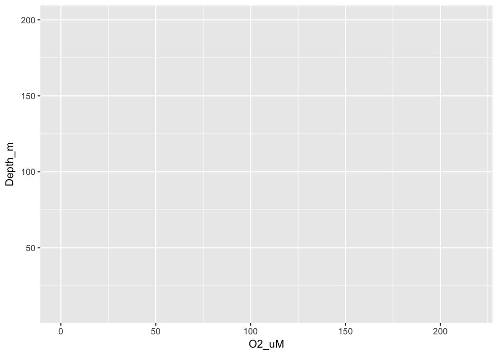

```r
ggplot(metadata, aes(x=O2_uM, y=Depth_m))
```

To add in the data, we must specify a geom. To get a dot plot, we will use `geom_point`. Notice that we don’t need to pass any variables to the geom function. This is because when not specified within the geom, ggplot takes these data from the base `ggplot` function.

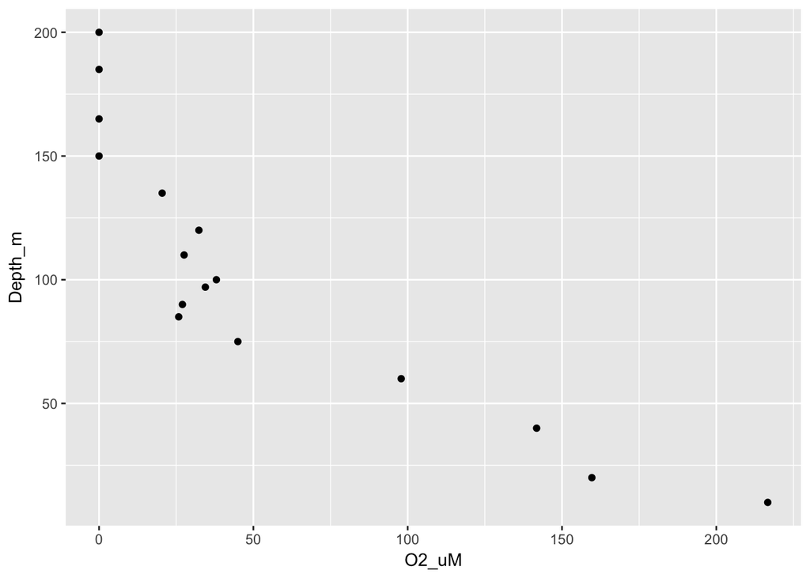

```r
ggplot(metadata, aes(x=O2_uM, y=Depth_m)) +
  geom_point()
```

So, the above is equivalent to

```r
ggplot(metadata) +
  geom_point(aes(x=O2_uM, y=Depth_m))
```

## Color, shape, size

We can change the color (outline and fill), shape, or size of our points by continuing to modify the aesthetics.

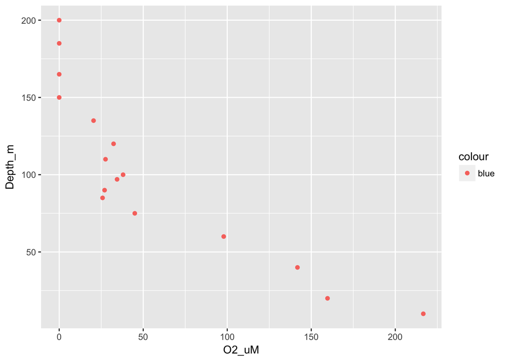

```r
ggplot(metadata, aes(x=O2_uM, y=Depth_m, color="blue")) +
  geom_point()
```

**But wait! That’s not blue! What happened?**

What happened is geoms cannot get all of their data from the `ggplot` function. Within `ggplot`, you can specify attributes that are part of the overall plot (everything that shows up if you only use `ggplot`, no geom) but not attributes associated with a specific geom. In this case, the dots are there because of `geom_point` so we must change their color within the geom function.

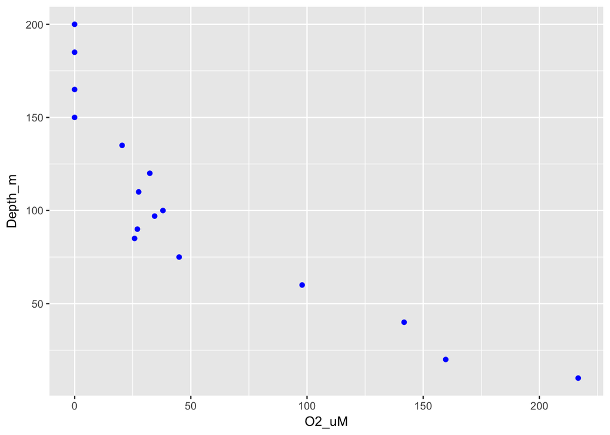

```r
ggplot(metadata, aes(x=O2_uM, y=Depth_m)) +
  geom_point(color="blue")
```

The same holds for changing shape and size such as in

```r
ggplot(metadata, aes(x=O2_uM, y=Depth_m)) +
  geom_point(shape="square")

ggplot(metadata, aes(x=O2_uM, y=Depth_m)) +
  geom_point(size=10)
```

We can also add a third variable to our plot by including it as color, shape, or size of dots. This works for both continuous and categorical variables.

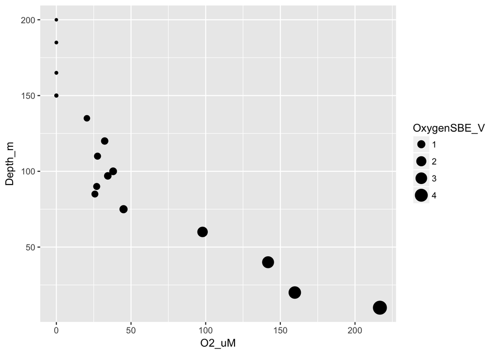

```r
ggplot(metadata, aes(x=O2_uM, y=Depth_m, size=OxygenSBE_V)) +
  geom_point()
```

Unsurprisingly, oxygen concentrations in both units correlate with each other.

# Exercise 1

Plot another nutrient of your choice against depth. Change the points to be purple triangles. For a guide to R shapes, see [here](http://sape.inf.usi.ch/sites/default/files/ggplot2-shape-identity.png).

Example

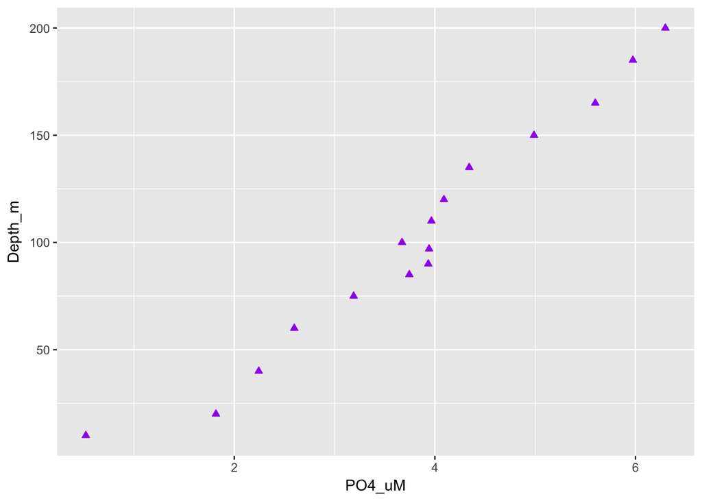

# ggplot with dplyr

As we saw briefly in our last Data Science Friday, data modified using `dplyr` can be directly piped into a ggplot function.

Let’s plot temperature in Fahrenheit against depth. But wait! Our temperature variable is in Celsius. We will need to first convert temperature and then pipe that data into ggplot

# Exercise 2

Using `dplyr`, convert the temperature variable from Celsius to Fahrenheit. Then create a dot plot of temperature in Fahrenheit against depth.

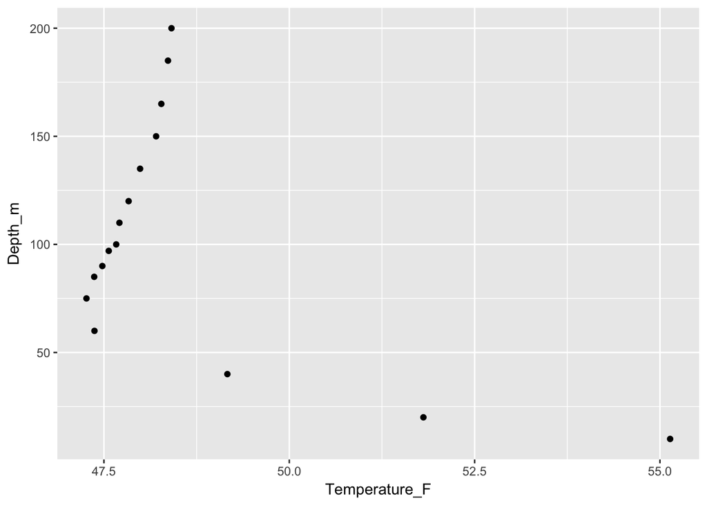

# gglot with phyloseq

Another package that plays nice with `ggplot` is `phyloseq`, which is designed to complete alpha- and beta-diversity analyses as well as visualization of sequencing data. As stated in the introduction, we have already created a phyloseq object for your use today.

```r
physeq
```

```
## phyloseq-class experiment-level object
## otu_table()   OTU Table:         [ 4368 taxa and 7 samples ]
## sample_data() Sample Data:       [ 7 samples by 22 sample variables ]
## tax_table()   Taxonomy Table:    [ 4368 taxa by 7 taxonomic ranks ]
## phy_tree()    Phylogenetic Tree: [ 4368 tips and 4366 internal nodes ]
```

This is the bacterial 16S OTU sequence data associated with 7 of the depths within our geochemical metadata. We see that this phyloseq object contains

- OTU table for 4368 OTUs across the 7 samples
- Metadata (called sample data)
- Taxonomy table denoting the classifications of all of the 4368 OTUs
- Phylogenetic tree detailing the the relatedness of all 4368 OTUs

What makes it worth it to use `phyloseq` is its inherent understanding of taxonomy. So instead of writing a complex `mutate` function to, say, add together all OTUs at the phylum level, we can just use phyloseq to do that.

`phyloseq` plot functions mirror `ggplot` like `plot_bar` = `geom_bar`. For example, we can plot the phylum level communities by depth by simply specifying the fill.

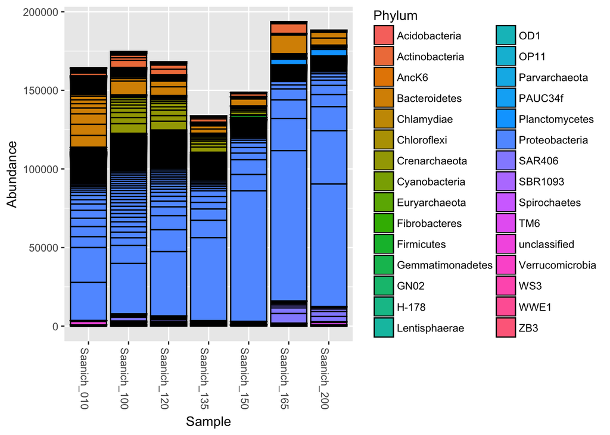

```r
plot_bar(physeq, fill="Phylum")
```

This would not work in `ggplot` without `phyloseq` because `ggplot` does not understand a phyloseq object or its pieces.

However, when we look at this plot, we see that we have a different total number of sequences (Abundance) in each sample. So, our bars do not all go up to the same level.

We could use `mutate` from `dplyr` to modify our OTU table to be percentages and then reform the phyloseq object for plotting. But since this is a common problem and `dplyr` is difficult to use directly on a phyloseq object, `phyloseq` has the function `transform_sample_counts` just for this purpose.

So, we can calculate a percentage of the total of each sample for each OTU with the following. The `function` applies the equation we give it (100*x/sum(x)) to every cell in our OTU table.

```r
physeq_percent = transform_sample_counts(physeq, function(x) 100 * x/sum(x))
```

Now, when we plot the phyla, we see 0-100% for all samples.

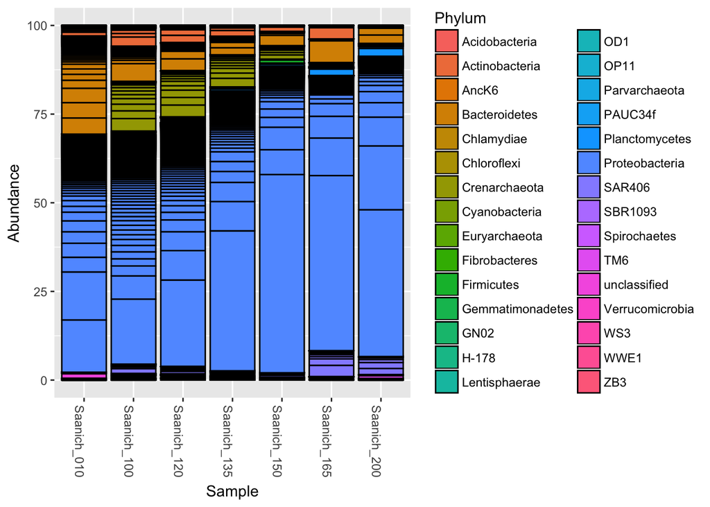

```r
plot_bar(physeq_percent, fill="Phylum")
```

But this still isn’t a great plot. There are black lines separating each OTU within a bar. This is great for highly abundant OTUs but creates wholly black regions when many low abundance OTUs are next to each other such that you can no longer see the phylum colors.

To remedy this, we add a geom from `ggplot`. By specifying `stat` as “identity” instead of the default “stat_count”, R no longer sees the OTUs as separate data and therefore, the separating lines do not occur.

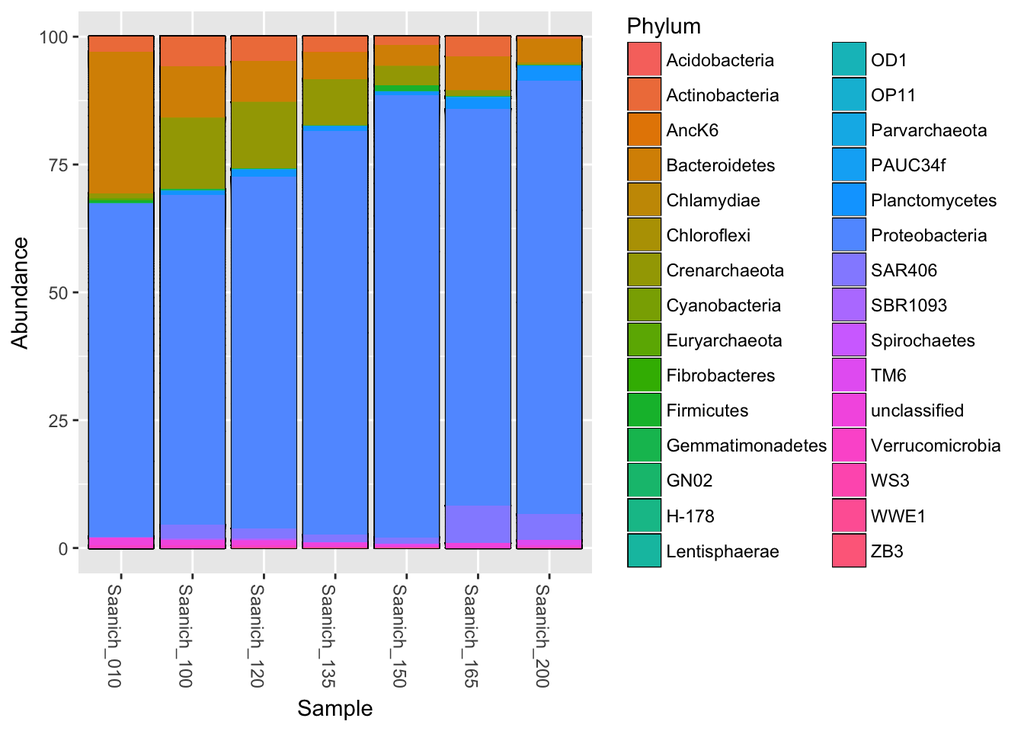

```r
plot_bar(physeq_percent, fill="Phylum") +
  geom_bar(aes(fill=Phylum), stat="identity")
```

# Exercise 3

Create a bar plot at a different taxonomic level with more descriptive x- and y-axis labels as well as a title. Use the `ggplot` cheatsheet to learn the guides needed to change these labels.

Example using phyla.

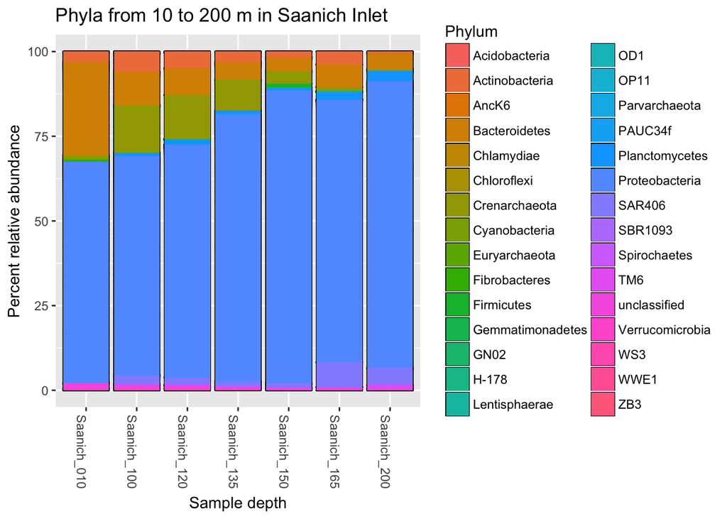

# Faceting

Another great feature of `ggplot` is faceting. We see in our stacked bar plots above that some low abundance taxa are so low that you can’t see them and some colors are so similar that it’s difficult to tell them apart.

When you have complex data like this, you can separate it into multiple panels (or facets) to more clearly see patterns. Working from our previous bar plot, we simply add `face_wrap` and tell it what variable to separate by.

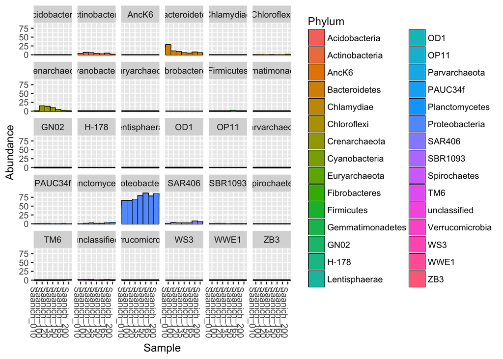

```r
plot_bar(physeq_percent, fill="Phylum") +
  geom_bar(aes(fill=Phylum), stat="identity") +
  facet_wrap(~Phylum)
```

However, since we have very variable abundance values, the default which forces all y-axes to be on the same scale doesn’t really work for us. We can let R scale independently in each panel with the `scales` parameter like so.

We also don’t really need a legend anymore because each facet it labeled. So we can remove this in the `theme`.

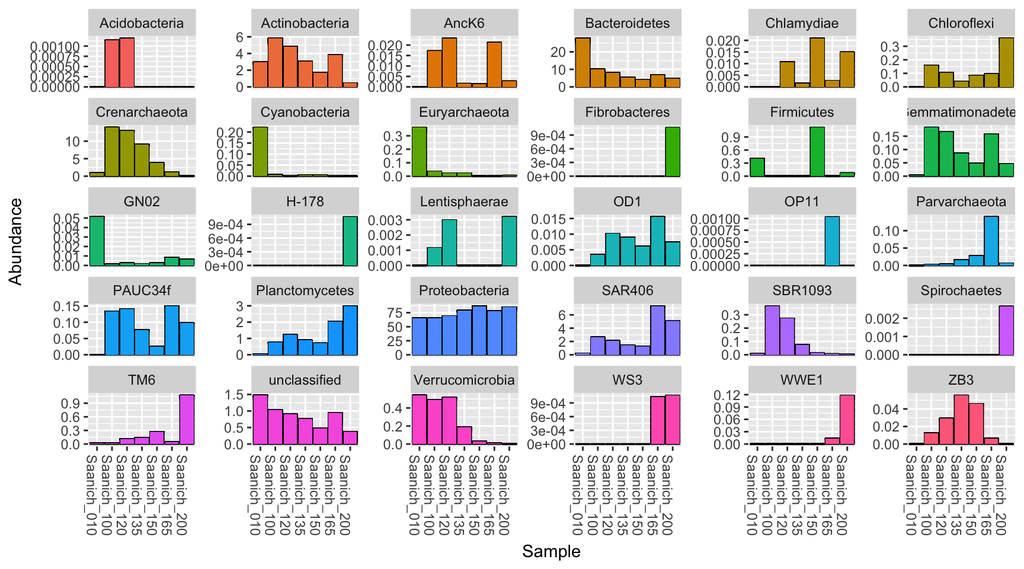

```r
plot_bar(physeq_percent, fill="Phylum") +
  geom_bar(aes(fill=Phylum), stat="identity") +
  facet_wrap(~Phylum, scales="free_y") +
  theme(legend.position="none")
```

Now we can clearly see how each phylum changes with depth.

# Exercise 4

Using `ggplot`, create a faceted figure showing nutrient concentrations in uM for O<sub>2</sub>, PO<sub>4</sub>, SiO<sub>2</sub>, NO<sub>3</sub>, NH<sub>4</sub>, and NO<sub>2</sub> by depth. For this, you can use either the metadata table or the phyloseq object.

*Hint*: Explore the `dplyr` function `gather` to manipulate the metadata so that your nutrients of interest are all in one variable (column).

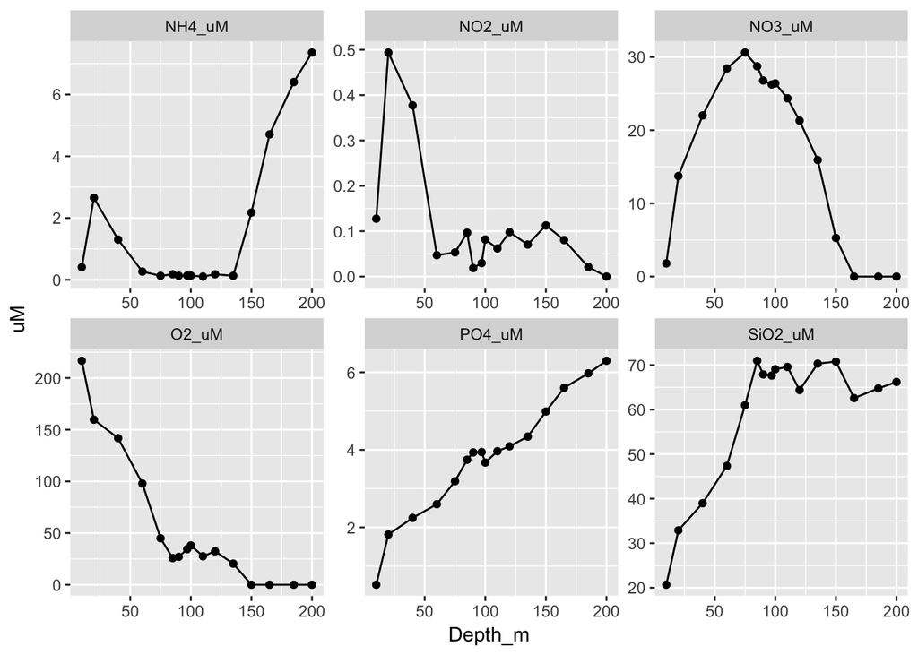

# Wrap-up

This tutorial covers just a few of the geoms and features of `ggplot`. We encourage you to practice more with the resources below and the up-coming [R workshop](https://www.eventbrite.ca/e/advanced-intro-to-r-workshop-series-march-2018-tickets-35922857233). These skills will be necessary moving into your projects in March.

# More resources

- [R cheatsheets](https://www.rstudio.com/resources/cheatsheets/)
- [ggplot tutorial 1](http://r-statistics.co/Complete-Ggplot2-Tutorial-Part1-With-R-Code.html)
- [ggplot tutorial 2](https://rpubs.com/g_jw/ggplot2_tutorial)
- [ggplot tutorial 3](http://tutorials.iq.harvard.edu/R/Rgraphics/Rgraphics.html#the_1_faq)
- [phyloseq demo](http://joey711.github.io/phyloseq-demo/phyloseq-demo.html)
- [phyloseq: Basic storage, access, and manipulation of sequencing data](https://bioconductor.org/packages/release/bioc/vignettes/phyloseq/inst/doc/phyloseq-basics.html)
- [phyloseq: Analysis of high-throughput microbiome census data](https://bioconductor.org/packages/release/bioc/vignettes/phyloseq/inst/doc/phyloseq-analysis.html)
- [phyloseq FAQ](https://bioconductor.org/packages/release/bioc/vignettes/phyloseq/inst/doc/phyloseq-FAQ.html)